# TP3 Real Estate

Kaabi Linda & Vhiny-Guilley Mombo

13/11/2020

## loading packages

```r
library(Metrics)
library(ggplot2)
library(corrplot)
library(bayestestR)
library(lars); library(MASS);library(glmnet)
```

## Lecture des données

On sépare les prix en 2 classes 0 et 1. Une transaction appartient à la classe 1 si son prix est supérieure à la médiane de la variable prix et 0 sinon. Préduire si une transaction appartient à une de ces 2 classes peut se faire par une régressions logistiques.

```r
tab=read.table("RealEstate.csv",header=TRUE,sep=',');
medianHousePrice=median(tab$Y.house.price.of.unit.area);
medHousePriceBin=as.numeric(tab$Y.house.price.of.unit.area>medianHousePrice);

##
tabmed = tab
tabmed = tabmed[,-1]
tabmed$Y.house.price.of.unit.area = medHousePriceBin
head(tabmed)
```

```
##   X1.transaction.date X2.house.age X3.distance.to.the.nearest.MRT.station
## 1            2012.917         32.0                               84.87882
## 2            2012.917         19.5                              306.59470
## 3            2013.583         13.3                              561.98450
## 4            2013.500         13.3                              561.98450
## 5            2012.833          5.0                              390.56840
## 6            2012.667          7.1                             2175.03000
##   X4.number.of.convenience.stores X5.latitude X6.longitude
## 1                              10    24.98298     121.5402
## 2                               9    24.98034     121.5395
## 3                               5    24.98746     121.5439
## 4                               5    24.98746     121.5439
## 5                               5    24.97937     121.5425
## 6                               3    24.96305     121.5125
##   Y.house.price.of.unit.area
## 1                          0
## 2                          1
## 3                          1
## 4                          1
## 5                          1
## 6                          0
```

```r
colnames(tabmed)[dim(tabmed)[2]] <- "medHousePriceBin" # change la variable price en medHousePriceBin dans le tableau.
head(tabmed)
```

```
##   X1.transaction.date X2.house.age X3.distance.to.the.nearest.MRT.station
## 1            2012.917         32.0                               84.87882
## 2            2012.917         19.5                              306.59470
## 3            2013.583         13.3                              561.98450
## 4            2013.500         13.3                              561.98450
## 5            2012.833          5.0                              390.56840
## 6            2012.667          7.1                             2175.03000
##   X4.number.of.convenience.stores X5.latitude X6.longitude medHousePriceBin
## 1                              10    24.98298     121.5402                0
## 2                               9    24.98034     121.5395                1
## 3                               5    24.98746     121.5439                1
## 4                               5    24.98746     121.5439                1
## 5                               5    24.97937     121.5425                1
## 6                               3    24.96305     121.5125                0
```

## visualisation des données

Le plot des différentes covariables nous permet de distinguer les dependances a priori entre elles.

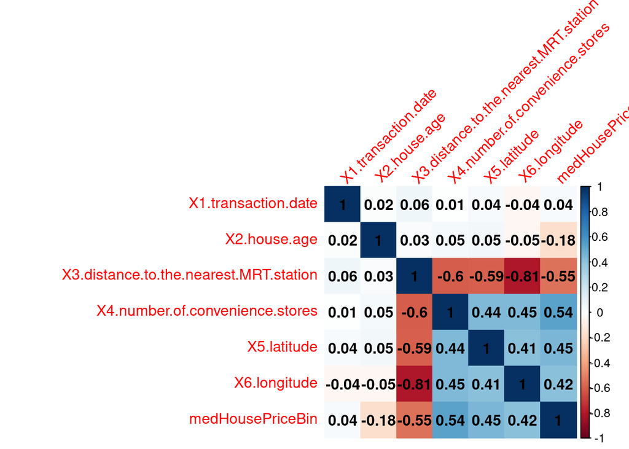

```r
mcor = cor(tabmed) # correlation matrix
corrplot(mcor, method="color", addCoef.col= "black", tl.srt =
45, sig.level=0.01, insig="blank")
```

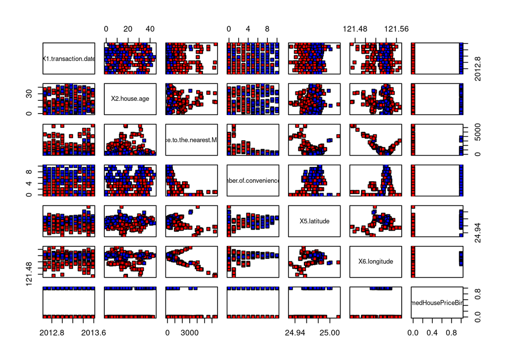

```r
pairs(tabmed,pch=22,bg=c("red","blue")[unclass(factor(tabmed[,"medHousePriceBin"]))]) #
```

```r
#dans le plot les points rouges sont les transactions dont le prix sont
# en dessous de la mediane [0], et le bleus celles au dessus [1]
```

Dans ce graphe les points bleus sont les transactions dont le prix est supérieur à la médiane et les rouges sont celles dont le prix est inférieur. A part, X1.transaction.date/X2.house.date, sur lequel on peut pas distinguer des clusters, sur les autres plots , on voit nettement des clusterS se former dans chacun des covariables plots. La proximité à la station la plus proche X3 est une variables fortement corrélée avec la X6.longitude.

# I) Les modèles.

Dans la suite on va essayer de generer differents modèles à partir des regression logistique sur notre eu de données:

On commencera par un modèle dit “full”, qui utiliseras toutes les variables, ensuite on fera une selection de variables grace une méthode “stepwise”, puis on fera des regressions logistiques sous contraintes classiques en utilisant “ridge” et “lasso”.

### organisation du dataset

on va partitionner notre jeu de données en training et test avec des proportions respectives de 80% et 20%.

```r
set.seed(1234) #assure la repetabilité des differents pocessus aleatoire
p = 0.8 # represente 80% qui va  etre pour le trainin set
ind = sample(2, nrow(tabmed), replace = T, prob = c(p,1-p)) ## selectionne les indices
#aleatoirent entre 2 groupe, le premiere groupe represente 80 % de l'ensemble
#des indices et le 2e groupe le reste.
tab.train = as.data.frame(tabmed[ind == 1,]) #training dataset
tab.test = as.data.frame(tabmed[ind == 2,]) #test dataset

X.train = as.matrix(tab.train[,-dim(tab.train)[2]])
X.test = as.matrix(tab.test[,-dim(tab.test)[2]])
Y.test = tab.test$medHousePriceBin
Y.train = tab.train$medHousePriceBin
```

## I.1 Modele full

### a) model full

```r
model.full = glm(medHousePriceBin ~ ., data = tab.train, family = 'binomial')
summary(model.full)
```

```
##
## Call:
## glm(formula = medHousePriceBin ~ ., family = "binomial", data = tab.train)
##
## Deviance Residuals:
##     Min       1Q   Median       3Q      Max
## -2.3966  -0.3026   0.1507   0.5368   3.1611
##
## Coefficients:
##                                          Estimate Std. Error z value Pr(>|z|)
## (Intercept)                            -2.404e+03  3.908e+03  -0.615  0.53834
## X1.transaction.date                     1.381e+00  6.299e-01   2.193  0.02834
## X2.house.age                           -7.016e-02  1.460e-02  -4.807 1.53e-06
## X3.distance.to.the.nearest.MRT.station -2.596e-03  5.141e-04  -5.049 4.44e-07
## X4.number.of.convenience.stores         2.619e-01  8.212e-02   3.189  0.00143
## X5.latitude                             9.477e+01  2.235e+01   4.241 2.22e-05
## X6.longitude                           -2.255e+01  3.117e+01  -0.723  0.46946
##
## (Intercept)
## X1.transaction.date                    *
## X2.house.age                           ***
## X3.distance.to.the.nearest.MRT.station ***
## X4.number.of.convenience.stores        **
## X5.latitude                            ***
## X6.longitude
## ---
## Signif. codes:  0 '***' 0.001 '**' 0.01 '*' 0.05 '.' 0.1 ' ' 1
##
## (Dispersion parameter for binomial family taken to be 1)
##
##     Null deviance: 467.11  on 336  degrees of freedom
## Residual deviance: 221.48  on 330  degrees of freedom
## AIC: 235.48
##
## Number of Fisher Scoring iterations: 7
```

Avec un seuil de p-value à 0.01, les variables statistiquement significatives sont X2,X3,X4 et X5. De plus le test rejete la varible X6.longitude. Ce qui est sans doute du à la corrélation de celle ci avec X3.

### b) Prediction avec le model full

```r
 ### prediction
prob = predict.glm(model.full, newdata = tab.test,type = "response") # give the predicted probability
OR_full = exp(model.full$coefficients) # odd ratio
OR_full
```

```
##                            (Intercept)                    X1.transaction.date
##                           0.000000e+00                           3.979501e+00
##                           X2.house.age X3.distance.to.the.nearest.MRT.station
##                           9.322441e-01                           9.974075e-01
##        X4.number.of.convenience.stores                            X5.latitude
##                           1.299354e+00                           1.439174e+41
##                           X6.longitude
##                           1.609538e-10
```

Une augmentation de X4 le nombre de magasins de proximité, et la latitute X5 ou la date de transaction X1 semble augmenter augmenter le prix de la transaction. Tandis que une augmententation des autres variables telles que le l’age de maison X2, la longitude X6 ou la distance a la station la plus proche X3 semble diminuer le prix de la transaction.

### c) Performance du model full

```r
Threshold = 0.5 # for MAE estimation
Y.pred.full =  as.integer(prob >= Threshold)
confusion_matrix.full = table(Y.pred.full,tab.test$medHousePriceBin)
confusion_matrix.full
```

```
##
## Y.pred.full  0  1
##           0 33  9
##           1  8 27
```

```r
accuracy.full = sum(diag(confusion_matrix.full))/sum(confusion_matrix.full)*100#
  recall.full = confusion_matrix.full[2,2]/sum(confusion_matrix.full[,2])*100 #
  precision.full =confusion_matrix.full[2,2]/sum(confusion_matrix.full[2,])*100
  error_rate.full = sum(diag(confusion_matrix.full[1:2,2:1]))/sum(confusion_matrix.full) *100
```

Avec une specificité de 80% et un un recall de 75% le model full prédit assez bien les éléments de differentes classe. Globalement on fait une erreur de 22%, ce qui relativement bas au vu de la taille de l’echantillon.

Afin d’évaluer d’avoir une meilleur fiabilité à notre modèle on va effecteur une Validation croisée.

### d) k-folds pour le model full

```r
##shuffling
set.seed(1234)
rows <- sample(nrow(tabmed)) # melange des rows du dataset
tabmed <- tabmed[rows, ]
## folds
k = 15 #as.integer(1/(1-r)) ## fold number
fold = cut(seq(1,nrow(tabmed)), breaks = k,labels = FALSE) #organisations des lignes du
#dataset en plusieurs fold
#initialisation des vectueurs qui va contenier les performances a chaque etape
accuracyk.full = c()
recallk.full = c()
precisionk.full = c()
error_ratek.full = c()

for (i in 1:k) {
  test_rows = which(fold == i,arr.ind = TRUE) #selection des lignes qui correspondent
  # au fold i
  tab.testk = tabmed[test_rows,]
  tab.traink = tabmed[-test_rows,]
  ### regression logistic
  model.fullk=glm(medHousePriceBin~.,family=binomial,data = tab.traink)
  ### prediction
  prob = predict.glm(model.fullk, newdata = tab.testk,type = "response") # give probability
  Y.pred.full =  as.integer(prob >= Threshold)  #MAE estimation
  confusion_matrix = table(Y.pred.full,tab.testk$medHousePriceBin)
  accuracyk.full[i] = sum(diag(confusion_matrix))/sum(confusion_matrix)*100#
  recallk.full[i] = confusion_matrix[2,2]/sum(confusion_matrix[,2])*100 #
  precisionk.full[i] =confusion_matrix[2,2]/sum(confusion_matrix[2,])*100
  error_ratek.full[i] = sum(diag(confusion_matrix[1:2,2:1]))/sum(confusion_matrix) *100
}
mean(recallk.full)
```

```
## [1] 86.26258
```

```r
mean(error_ratek.full)
```

```
## [1] 18.11287
```

```r
mean(accuracyk.full)
```

```
## [1] 81.88713
```

```r
mean(precisionk.full)
```

```
## [1] 78.74136
```

En utilisant le k-fold on évalue la precision du model. nous donne une bonne performance global. Avec une performance global de 80% et un taux d’erreur d’environ 20%.

## I.2) Regression Logistique avec selection de variable Stepwise

On a vu que certaines variables, comme X6.longitude était pas significative dans notre model full,dans cette partie, on va effectuer une selection de Variables, puis une regression logistique sur ces dernières.

### a) Resstep Model

Selection des variables à partir du model précédent.

```r
resstep<-step(model.full,direction='both'); summary(resstep)
```

```
## Start:  AIC=235.48
## medHousePriceBin ~ X1.transaction.date + X2.house.age + X3.distance.to.the.nearest.MRT.station +
##     X4.number.of.convenience.stores + X5.latitude + X6.longitude
##
##                                          Df Deviance    AIC
## - X6.longitude                            1   222.02 234.02
## <none>                                        221.48 235.48
## - X1.transaction.date                     1   226.41 238.41
## - X4.number.of.convenience.stores         1   232.81 244.81
## - X5.latitude                             1   242.44 254.44
## - X2.house.age                            1   248.18 260.18
## - X3.distance.to.the.nearest.MRT.station  1   265.27 277.27
##
## Step:  AIC=234.02
## medHousePriceBin ~ X1.transaction.date + X2.house.age + X3.distance.to.the.nearest.MRT.station +
##     X4.number.of.convenience.stores + X5.latitude
##
##                                          Df Deviance    AIC
## <none>                                        222.02 234.02
## + X6.longitude                            1   221.48 235.48
## - X1.transaction.date                     1   226.74 236.74
## - X4.number.of.convenience.stores         1   232.94 242.94
## - X5.latitude                             1   243.59 253.59
## - X2.house.age                            1   249.18 259.18
## - X3.distance.to.the.nearest.MRT.station  1   279.21 289.21
```

```
##
## Call:
## glm(formula = medHousePriceBin ~ X1.transaction.date + X2.house.age +
##     X3.distance.to.the.nearest.MRT.station + X4.number.of.convenience.stores +
##     X5.latitude, family = "binomial", data = tab.train)
##
## Deviance Residuals:
##     Min       1Q   Median       3Q      Max
## -2.3391  -0.2916   0.1624   0.5223   3.1496
##
## Coefficients:
##                                          Estimate Std. Error z value Pr(>|z|)
## (Intercept)                            -5.072e+03  1.404e+03  -3.612 0.000304
## X1.transaction.date                     1.348e+00  6.286e-01   2.145 0.031950
## X2.house.age                           -7.077e-02  1.461e-02  -4.843 1.28e-06
## X3.distance.to.the.nearest.MRT.station -2.417e-03  4.475e-04  -5.400 6.66e-08
## X4.number.of.convenience.stores         2.392e-01  7.401e-02   3.232 0.001231
## X5.latitude                             9.448e+01  2.205e+01   4.284 1.83e-05
##
## (Intercept)                            ***
## X1.transaction.date                    *
## X2.house.age                           ***
## X3.distance.to.the.nearest.MRT.station ***
## X4.number.of.convenience.stores        **
## X5.latitude                            ***
## ---
## Signif. codes:  0 '***' 0.001 '**' 0.01 '*' 0.05 '.' 0.1 ' ' 1
##
## (Dispersion parameter for binomial family taken to be 1)
##
##     Null deviance: 467.11  on 336  degrees of freedom
## Residual deviance: 222.02  on 331  degrees of freedom
## AIC: 234.02
##
## Number of Fisher Scoring iterations: 7
```

Sans surprise, comme vu dans le TP2, la variable X6.longitude a été éliminée dans la sélection de variables, ce qui augmente la significaivité des autres variables, c’est ce qu’on remarque en comparant les test effectués sur une régression logistique de type full (toutes les variables) et les test sur une régression logistique de type stepwise.

```r
OR_step=exp(resstep$coefficients) # give the odd ratios on stepwise model
OR_step
```

```
##                            (Intercept)                    X1.transaction.date
##                           0.000000e+00                           3.850789e+00
##                           X2.house.age X3.distance.to.the.nearest.MRT.station
##                           9.316744e-01                           9.975862e-01
##        X4.number.of.convenience.stores                            X5.latitude
##                           1.270203e+00                           1.074748e+41
```

Comme precedemment, les variables X1.transaction date, X4.convenience.stores et X5.latitude, leur augmentation semble entrainer une augmentation de la probabilité que medHousePriceBin soit au-dessus de la médiane du prix de vente, au risque de 5%.

## b ) Prédiction sur le model stepwise

```r
prob= predict.glm(resstep, newdata = tab.test,type = "response") # give the predicted prob on the stepwise model
pred_step=as.numeric(prob>Threshold) #
```

On calcule les prédictions contruites à partir de ce modèle pred_step qui donne la valeur des $\hat\eta$ pour tous les individus dans le data set test. pred_step vaut 1 si pred_step > 1/2.

```r
confusion_matrix.step = table(pred_step,tab.test$medHousePriceBin)
confusion_matrix.step
```

```
##
## pred_step  0  1
##         0 33  7
##         1  8 29
```

La matrice de confusion nous montre qu’on predit mieux de vrai evenements qu’on en fait des erreurs.

```r
pred.accuracy.step = sum(diag(confusion_matrix.step))/sum(confusion_matrix.step)*100
#prediction accuracy
pred.recall.step = confusion_matrix.step[2,2]/sum(confusion_matrix.step[,2])*100
# probabilité que la prediction des hauts prix soit correctes
pred.specifity.step = confusion_matrix.step[1,1]/sum(confusion_matrix.step[,1])*100
# probabilité que la prediction des bas prix soit correctes
pred.precision.step = confusion_matrix.step[2,2]/sum(confusion_matrix.step[2,])*100
#
pred.error_rate.step = sum(diag(confusion_matrix.step[1:2,2:1]))/sum(confusion_matrix.step) *100 # probabilité d'obtenir une erreur

pred.accuracy.step
```

```
## [1] 80.51948
```

```r
pred.recall.step
```

```
## [1] 80.55556
```

```r
pred.specifity.step
```

```
## [1] 80.4878
```

```r
pred.error_rate.step
```

```
## [1] 19.48052
```

Comme dit precedemment mais avec des chiffres, on effectue des bonnes prédictions en moyenne à 80.5%. Ce qui est pas un bon score au vu de la taille de l’échantillon.

### Courbe ROC et AUC

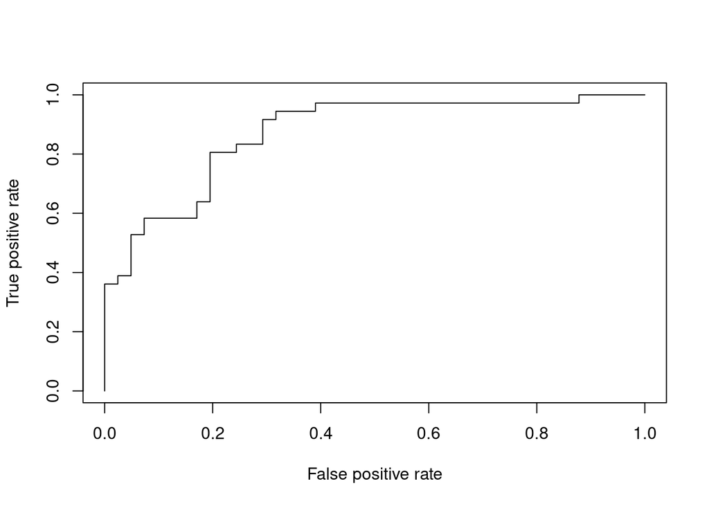

```r
library(ROCR)

pred=prediction(prob,tab.test$medHousePriceBin)
perf=performance(pred, "tpr" ,"fpr")
plot(perf)
```

La courbe est assez proche du coin supérieur gauche, ainsi le modèle semble capturer le plus possible de vrais évènements avec le moins possible de faux évènements.

```r
ROC_auc=performance(pred,"auc")
AUC=ROC_auc@y.values[[1]]
print(AUC)
```

```
## [1] 0.8712737
```

### c) k-fold pour le model stepwise

On effectue 15 folds

```r
rows=sample(nrow(tabmed))
tabmedk=tabmed[rows,]

## folds

k=15
fold=cut(seq(1,nrow(tabmed)),breaks=k, labels=FALSE)
##
accuracyk.step=c()
recallk.step=c()
error_ratek.step=c()
precisionk.step=c()

for (i in 1:k){
  test_rows=which(fold==i, arr.ind=TRUE)
  tab.testk=tabmedk[test_rows,]
  tab.traink=tabmedk[-test_rows,]

  # regression logistique
  model.full=glm(medHousePriceBin~., family=binomial, data=tab.traink)
  model.stepk=step(model.full,direction='both')

  # prediction

  pred_stepk=predict.glm(model.stepk, newdata= tab.testk, type="response")
  Y.pred.step=as.numeric(pred_stepk>=Threshold)
  confusion_matrix=table(Y.pred.step, tab.testk$medHousePriceBin)
  accuracyk.step[i]=sum(diag(confusion_matrix))/sum(confusion_matrix)*100 # prediction accuracy
  precisionk.step[i] =confusion_matrix[2,2]/sum(confusion_matrix[2,])*100
  recallk.step[i]=confusion_matrix[2,2]/sum(confusion_matrix[,2])*100
  error_ratek.step[i]=sum(diag(confusion_matrix[1:2,2:1]))/sum(confusion_matrix)*100
}
```

[output not shown]

[output cut: 320 more lines]

[output not shown]

```r
mean(recallk.step)
```

```
## [1] 87.42318
```

```r
mean(error_ratek.step)
```

```
## [1] 17.60141
```

```r
mean(accuracyk.step)
```

```
## [1] 82.39859
```

```r
mean(precisionk.step)
```

```
## [1] 80.56085
```

En utilisant la validation croisée, on remarque que nous avons une performance globale qui se situe autour de 80%, avec un taux d’erreur autour de 20%.

## I.3 Ridge regression

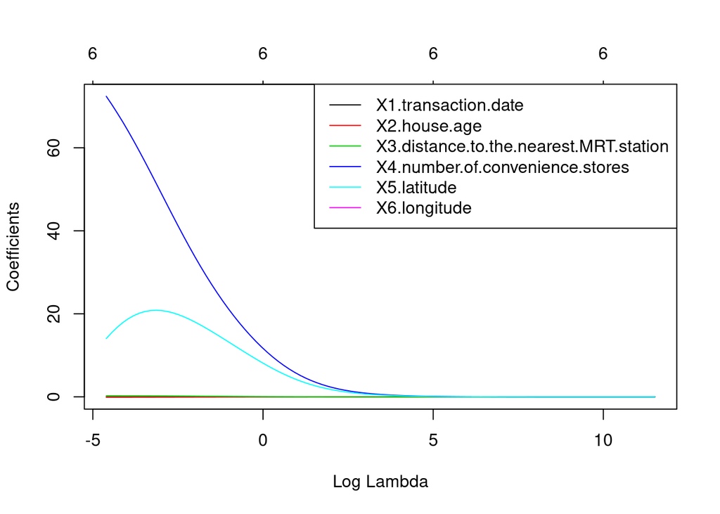

```r
grid = 10^seq(5,-2,length = 100) # sequence des lambda
model.ridge <- glmnet(X.train,Y.train,alpha=0,lambda = grid,family = "binomial") # model
plot(model.ridge,xvar="lambda",type="l",col=1:nrow(tab.train)-1);legend("topright"                                                            ,legend=colnames(tab.train[,1:ncol(tab.train)-1]), col=1:10, lty=1)
```

### b) Selection du $\lambda$ par cross validation

```r
####################### cross validation
ridge.cv.out<-cv.glmnet(X.train, Y.train, alpha = 0,nfolds = 10,family = "binomial"); ridge.cv.out # on sélectionne la meilleure valeur de lambda par validation croisée
```

```
##
## Call:  cv.glmnet(x = X.train, y = Y.train, nfolds = 10, alpha = 0, family = "binomial")
##
## Measure: Binomial Deviance
##
##      Lambda Measure      SE Nonzero
## min 0.02884  0.7427 0.03697       6
## 1se 0.05531  0.7756 0.03343       6
```

```r
ridge.lamb.min<-ridge.cv.out$lambda.min # le meilleur lambda est celui qui produit the min MSE
```

On selectionne le modele le lambda qui minimise le MSE pour notre modèle. On effectue 10 folds.

### c) Prediction du model Ridge

```r
ridge.pred <- predict(model.ridge, s = ridge.lamb.min, newx = X.test,type = 'response')
Y.pred.ridge =  as.integer(ridge.pred >= Threshold)
confusion_matrix.ridge = table(Y.pred.ridge,Y.test) # matrice de confusion
confusion_matrix.ridge
```

```
##             Y.test
## Y.pred.ridge  0  1
##            0 31  8
##            1 10 28
```

### d) Performance du model

```r
pred.accuracy.ridge = sum(diag(confusion_matrix.ridge))/sum(confusion_matrix.ridge)*100#   prediction accuracy
pred.recall.ridge = confusion_matrix.ridge[2,2]/sum(confusion_matrix.ridge[,2])*100 # proportion des hauts prix bien predit
pred.specifity.ridge = confusion_matrix.ridge[1,1]/sum(confusion_matrix.ridge[,1])*100 # proportion des bas prix bien predits
pred.precision.ridge = confusion_matrix.ridge[2,2]/sum(confusion_matrix.ridge[2,])*100
pred.error_rate.ridge =
sum(diag(confusion_matrix.ridge[1:2,2:1]))/sum(confusion_matrix.ridge) *100 # proportion des mauvaises predictions

pred.accuracy.ridge
```

```
## [1] 76.62338
```

```r
pred.recall.ridge
```

```
## [1] 77.77778
```

```r
pred.specifity.ridge
```

```
## [1] 75.60976
```

```r
pred.error_rate.ridge
```

```
## [1] 23.37662
```

On retrouve une performance de 76% sur le modèle. Le modèle predit bien la classe des hauts prix à 77% et celle de pas prix à 75%.

### e) k-folds le model ridge

```r
##shuffling
set.seed(1234)
rows <- sample(nrow(tabmed)) # melange des rows du dataset
tabmedk <- tabmed[rows, ]
## folds
k = 15 #as.integer(1/(1-r)) ## fold number
fold = cut(seq(1,nrow(tabmed)), breaks = k,labels = FALSE) #organisations des lignes du
#dataset en plusieurs fold
#initialisation des vectueurs qui va contenier les performances a chaque etape
accuracyk.ridge = c()
recallk.ridge = c()
precisionk.ridge = c()
error_ratek.ridge = c()
for (i in 1:k) {
  test_rows = which(fold == i,arr.ind = TRUE)
  tab.testk = tabmedk[test_rows,]
  tab.traink = tabmedk[-test_rows,]
  X.traink = as.matrix(tab.traink[,-dim(tab.traink)[2]])
  X.testk = as.matrix(tab.testk[,-dim(tab.testk)[2]])
  Y.testk = tab.testk$medHousePriceBin
  Y.traink = tab.traink$medHousePriceBin
  ### regression logistic
  model.ridgek <- glmnet(X.traink,Y.traink,alpha=0,lambda = grid,family = "binomial")
  ### prediction
  ####################### cross validation
  ridge.cv.out<-cv.glmnet(X.traink, Y.traink, alpha = 0,nfolds = 10,family = "binomial") # on sélectionne la meilleure valeur de lambda par validation croisée
  ridge.lamb.mink<-ridge.cv.out$lambda.min # le meilleur lambda est celui qui produit the min MSE

  prob <- predict(model.ridgek, s = ridge.lamb.mink, newx = X.testk,type = 'response')
  Y.pred.ridge =  as.integer(prob >= Threshold)
  confusion_matrix = table(Y.pred.ridge,tab.testk$medHousePriceBin)
  accuracyk.ridge[i] = sum(diag(confusion_matrix))/sum(confusion_matrix)*100
  recallk.ridge[i] = confusion_matrix[2,2]/sum(confusion_matrix[,2])*100
  precisionk.ridge[i] =confusion_matrix[2,2]/sum(confusion_matrix[2,])*100
  error_ratek.ridge[i] = sum(diag(confusion_matrix[1:2,2:1]))/sum(confusion_matrix) *100
}

mean(recallk.ridge)
```

```
## [1] 86.68707
```

```r
mean(error_ratek.ridge)
```

```
## [1] 18.61552
```

```r
mean(accuracyk.ridge)
```

```
## [1] 81.38448
```

```r
mean(precisionk.ridge)
```

```
## [1] 78.41565
```

## I.4) Modèle Lasso

### a) Model Lasso

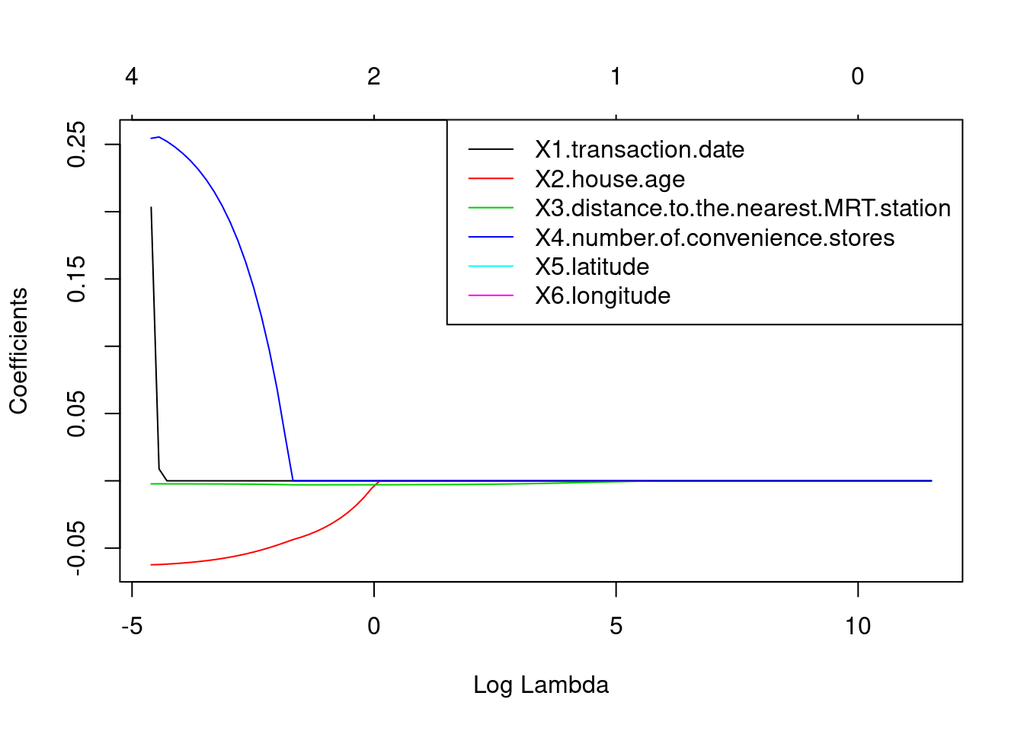

```r
grid = 10^seq(5,-2,length = 100) # sequence des lambda
lasso=glmnet(X.train,Y.train,alpha=1,lambda=grid,family = "binomial", standardize=FALSE)
plot(lasso,xvar="lambda",type="l",col=1:10);legend("topright",legend=colnames(X.train[,1:ncol(X.train)]), col=1:10, lty=1)
```

On voit que plus lambda est grand, plus le nombre de variables sélectionnées est petit.

### b) Selection du $\lambda$ par cross validation

```r
lasso.cv.out=cv.glmnet(X.train, Y.train, alpha = 1,nfolds = 10,family = "binomial");
lasso.min=lasso.cv.out$lambda.min # on sélectionne le plus petit lambda qui minimise le MSE
```

On effectue une prediction en utlisant le lambda avec le lambda qui minimise le MSE

### c) Prediction du model Lasso

```r
prob= predict(lasso, s=lasso.min, newx=X.test, type="response")
lasso.pred=as.numeric(prob > Threshold) # transforme les données en données binaire avec un seuil de 1/2
```

### d) Performance du model

```r
confusion_matrix.lasso = table(lasso.pred,Y.test) # on crée la matrice de confusion
confusion_matrix.lasso
```

```
##           Y.test
## lasso.pred  0  1
##          0 30  7
##          1 11 29
```

```r
pred.accuracy.lasso = sum(diag(confusion_matrix.lasso))/sum(confusion_matrix.lasso)*100#   prediction accuracy
pred.recall.lasso = confusion_matrix.lasso[2,2]/sum(confusion_matrix.lasso[,2])*100 # proportion des hauts prix bien predit
pred.specifity.lasso = confusion_matrix.lasso[1,1]/sum(confusion_matrix.lasso[,1])*100 # proportion des bas prix bien predits
pred.precision.lasso = confusion_matrix.lasso[2,2]/sum(confusion_matrix.lasso[2,])*100
pred.error_rate.lasso =
sum(diag(confusion_matrix.lasso[1:2,2:1]))/sum(confusion_matrix.lasso) *100 # proportion des mauvaises predictions

pred.accuracy.lasso
```

```
## [1] 76.62338
```

```r
pred.recall.lasso
```

```
## [1] 80.55556
```

```r
pred.specifity.lasso
```

```
## [1] 73.17073
```

```r
pred.error_rate.lasso
```

```
## [1] 23.37662
```

## Courbe ROC et AUC

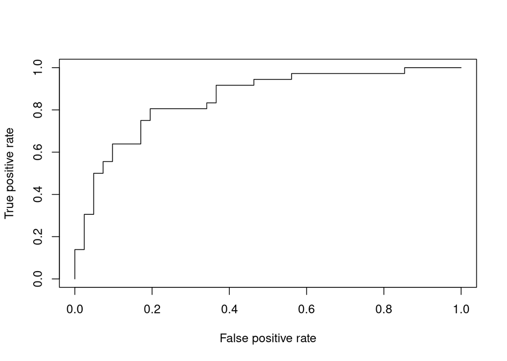

```r
pred.lasso=prediction(prob,tab.test$medHousePriceBin)
perf.lasso.min=performance(pred.lasso, "tpr" ,"fpr")
plot(perf.lasso.min)
```

La courbe est assez proche du coin supérieur gauche, ainsi le modèle semble capturer le plus possible de vrais évènements avec le moins possible de faux évènements.

```r
ROC_auc.lasso=performance(pred.lasso,"auc")
AUC.lasso=ROC_auc.lasso@y.values[[1]]
print(AUC.lasso)
```

```
## [1] 0.8523035
```

### e) K-folds le model lasso

```r
##shuffling
set.seed(1234)
rows <- sample(nrow(tabmed)) # melange des rows du dataset
tabmedk <- tabmed[rows, ]
## folds
k = 15 #as.integer(1/(1-r)) ## fold number
fold = cut(seq(1,nrow(tabmed)), breaks = k,labels = FALSE) #organisations des lignes du
#dataset en plusieurs fold
#initialisation des vectueurs qui va contenier les performances a chaque etape
accuracyk.lasso = c()
recallk.lasso = c()
precisionk.lasso = c()
error_ratek.lasso = c()
for (i in 1:k) {
  test_rows = which(fold == i,arr.ind = TRUE)
  tab.testk = tabmedk[test_rows,]
  tab.traink = tabmedk[-test_rows,]
  X.traink = as.matrix(tab.traink[,-dim(tab.traink)[2]])
  X.testk = as.matrix(tab.testk[,-dim(tab.testk)[2]])
  Y.testk = tab.testk$medHousePriceBin
  Y.traink = tab.traink$medHousePriceBin
  ### regression logistic
  model.lassok <- glmnet(X.traink,Y.traink,alpha=1,lambda = grid,family = "binomial")
  ### prediction
  ####################### cross validation
  lasso.cv.out<-cv.glmnet(X.traink, Y.traink, alpha = 1,nfolds = 10,family = "binomial")
  # on sélectionne la meilleure valeur de lambda par validation croisée
  lasso.lamb.mink<-lasso.cv.out$lambda.min # le meilleur lambda est celui qui produit the min MSE

  prob <- predict(model.lassok, s = lasso.lamb.mink, newx = X.testk,type = 'response')
  Y.pred.lasso =  as.integer(prob >= Threshold)
  confusion_matrix = table(Y.pred.lasso,tab.testk$medHousePriceBin)
  accuracyk.lasso[i] = sum(diag(confusion_matrix))/sum(confusion_matrix)*100
  recallk.lasso[i] = confusion_matrix[2,2]/sum(confusion_matrix[,2])*100
  precisionk.lasso[i] =confusion_matrix[2,2]/sum(confusion_matrix[2,])*100
  error_ratek.lasso[i] = sum(diag(confusion_matrix[1:2,2:1]))/sum(confusion_matrix) *100
}
mean(accuracyk.lasso)
```

```
## [1] 81.63139
```

```r
mean(recallk.lasso)
```

```
## [1] 88.45316
```

```r
mean(precisionk.lasso)
```

```
## [1] 78.3217
```

```r
mean(error_ratek.lasso)
```

```
## [1] 18.36861
```

# II )Conclusion

On va comparer les differents modeles entre eux.

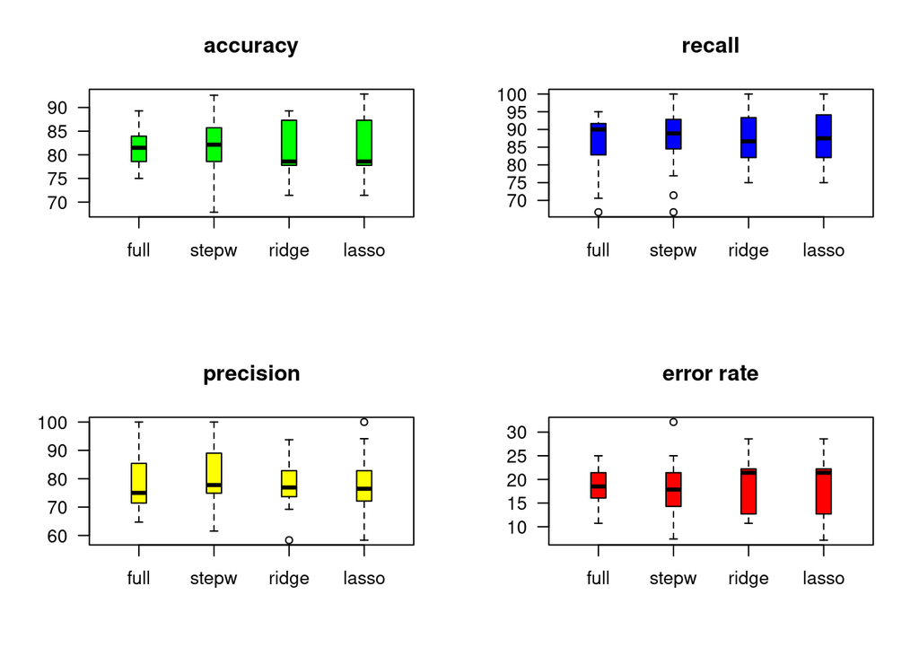

```r
par(mfrow = c(2,2))
boxplot(data.frame(accuracyk.full,accuracyk.step,accuracyk.ridge,accuracyk.lasso),col = "green",boxwex = 0.2, las = 1,names = c("full","stepw","ridge","lasso"),main = "accuracy")
boxplot(data.frame(recallk.full,recallk.step,recallk.ridge,recallk.lasso),col = "blue",boxwex = 0.2, las = 1,names = c("full","stepw","ridge","lasso"),main = "recall")
boxplot(data.frame(precisionk.full,precisionk.step,precisionk.ridge,precisionk.lasso),col = "yellow",boxwex = 0.2, las = 1,names = c("full","stepw","ridge","lasso"),main = "precision")
boxplot(data.frame(error_ratek.full,error_ratek.step,error_ratek.ridge,error_ratek.lasso),col = "red",boxwex = 0.2, las = 1,names = c("full","stepw","ridge","lasso"),main = "error rate")
```